# Fed Up with Uncertainty

- Show All Code
- Hide All Code
- View Source

Forecasting US GDP growth with an AR(1): from FRED data to density forecasts

Author

Viktor Gradoux

Published

13 October 2026

Abstract

We build, end to end, the kind of GDP forecast a central-bank forecasting division produces: download real GDP from FRED, transform it, choose and estimate a model, check it, forecast with uncertainty bands, and evaluate the forecasts out of sample. The model is deliberately the simplest one, an AR(1), so that every step stays visible.

# The question and the plan

**Question.** What will US real GDP growth be over the next four quarters, and how uncertain is that forecast?

**Model.** The simplest dynamic model there is, an autoregression of order one:

$$y_t = c + \phi\, y_{t-1} + \varepsilon_t, \qquad \varepsilon_t \sim WN(0,\sigma^2), \qquad \mu = \frac{c}{1-\phi},$$

where $y_t = 100\,(\log Y_t - \log Y_{t-1})$ is quarterly GDP growth in percent.

**Three samples.** Everything that is *chosen* (transformation, order $p$, checks) is decided on the first part of the data only. The rest is kept aside to judge the forecasts honestly.

```
1985Q1 ............. R = 2009Q4 ................. T (last quarter)
|---- estimation sample ----|------ evaluation sample ------|
  Sections 2-3 (choose, fit)  Sections 5-6 (forecast, evaluate)
```

The final forecast (Section 4) re-estimates the model on everything up to $T$.

**How to use this document**

Click **Show the R code** to unfold any chunk. The `</> Code` button at the top right lets you copy the whole source. All numbers in the text are computed when the document is rendered, so they update automatically with each new FRED release.

# Packages

Three packages beyond base R. Missing ones are installed the first time. In the code, every function that comes from a package is written as `package::function()` (for example `stats::arima()`, `urca::ur.df()`), so you always see where it comes from.

```r
packages <- c("fredr",   # FRED API client
              "urca",    # unit-root tests: augmented Dickey-Fuller
              "knitr")   # tables in this document
missing <- packages[!vapply(packages, requireNamespace, logical(1), quietly = TRUE)]
if (length(missing) > 0) utils::install.packages(missing, repos = "https://cloud.r-project.org")

library(fredr)
library(urca)
library(knitr)
# stats, utils and graphics are part of base R and always loaded
```

# Settings

Everything you may want to change is here.

```r
series_id    <- "GDPC1"                     # real GDP, quarterly, seasonally adjusted (FRED)

est_start    <- as.Date("1985-01-01")       # first quarter of the sample
eval_start   <- as.Date("2009-10-01")       # R = last quarter of the estimation sample = first forecast origin

H            <- 4                           # forecast horizon (quarters)
n_origins    <- 6                           # number of vintages in the vintage table (Section 7)
p_max        <- 4                           # largest AR order compared with AIC / BIC
adf_lags     <- 4                           # lagged differences in the ADF test

winsor_level <- 0.99                        # winsorisation bounds: 0.5% and 99.5% quantiles of the whole sample
gfc          <- as.Date(c("2007-10-01", "2009-04-01"))   # Great Financial Crisis (NBER: 2007Q4-2009Q2)
covid        <- as.Date(c("2020-01-01", "2021-10-01"))   # COVID; also excluded in "ex-COVID" results
```

**Show the helpers (colours, labels, small functions)**

```r
navy <- "#1F3A7D"; red <- "#BE3C32"; grey <- "grey55"; lightnavy <- "#C9D3EA"

qlab  <- function(d) paste0(format(d, "%Y"), "Q", (as.integer(format(d, "%m")) - 1) %/% 3 + 1)  # date -> "2025Q4"
add_q <- function(d, k) seq(d, by = "3 months", length.out = k + 1)[k + 1]                      # date + k quarters
fmt   <- function(x, k = 2) formatC(x, format = "f", digits = k)                                # number -> text

# a clean table for the document
tab <- function(df, caption = NULL, align = NULL) knitr::kable(df, caption = caption, align = align, escape = FALSE, row.names = FALSE)

# standard look for base-R figures
nice_par <- function(...) par(mar = c(3, 4.2, 1.2, 1), las = 1, mgp = c(2.6, .7, 0), bty = "l",
                              col.axis = "grey25", fg = "grey45", ...)
```

# 1 Data: real-time access through FRED

FRED (Federal Reserve Bank of St. Louis) publishes `GDPC1`, US real GDP in chained 2017 dollars, quarterly and already seasonally adjusted.

**Getting a FRED key (free, 2 minutes)**

1. Create an account on fred.stlouisfed.org (*My Account*).
2. *My Account → API Keys → Request API Key*.
3. Write a one-line description of what you will use it for and accept the terms of use.
4. Copy the 32-character key. It is personal: do not share it and do not push it to GitHub.

Give it to the document in one of two ways: paste it in `fred_api_key` in the header (`params`), or, better, store it once in your `~/.Renviron` file as `FRED_API_KEY=your_key` and restart R.

The code tries three sources, in this order: (1) the FRED API through the `{fredr}` package, using your key; (2) the public FRED CSV link, which needs no key; (3) a saved copy in `data/GDPC1_snapshot.csv`.

**Show the R code**

```r
dir.create("data", showWarnings = FALSE)
key <- if (nzchar(params$fred_api_key)) params$fred_api_key else Sys.getenv("FRED_API_KEY")

get_with_key <- function() {                                   # (1) FRED API, with a key
  if (!nzchar(key)) return(NULL)
  fredr::fredr_set_key(key)
  out <- fredr::fredr_series_observations(series_id = series_id, observation_start = as.Date("1947-01-01"),
                                          frequency = "q", units = "lin")
  data.frame(date = as.Date(out$date), value = out$value)
}
get_csv_link <- function() {                                   # (2) public CSV link, no key
  x <- utils::read.csv(paste0("https://fred.stlouisfed.org/graph/fredgraph.csv?id=", series_id))
  data.frame(date = as.Date(x[[1]]), value = suppressWarnings(as.numeric(x[[2]])))
}
get_snapshot <- function() {                                   # (3) saved copy
  x <- utils::read.csv("data/GDPC1_snapshot.csv"); data.frame(date = as.Date(x$date), value = x$value)
}

source_used <- NA; raw <- NULL
for (src in c("FRED API (fredr)", "FRED CSV link", "saved copy data/GDPC1_snapshot.csv")) {
  raw <- tryCatch(switch(src, "FRED API (fredr)" = get_with_key(), "FRED CSV link" = get_csv_link(),
                         get_snapshot()), error = function(e) NULL)
  if (!is.null(raw) && nrow(raw) > 0) { source_used <- src; break }
}
if (is.null(raw)) stop("No data: add your FRED key in params (header) or check the internet connection.")

raw <- raw[order(raw$date), ]
raw <- raw[!is.na(raw$value), ]
if (source_used != "saved copy data/GDPC1_snapshot.csv")
  utils::write.csv(raw, "data/GDPC1_snapshot.csv", row.names = FALSE)   # refresh the saved copy
```

Data source used for this render: **saved copy data/GDPC1_snapshot.csv**. The series runs from **1947Q1** to **2026Q2** (318 quarters).

**Show the R code**

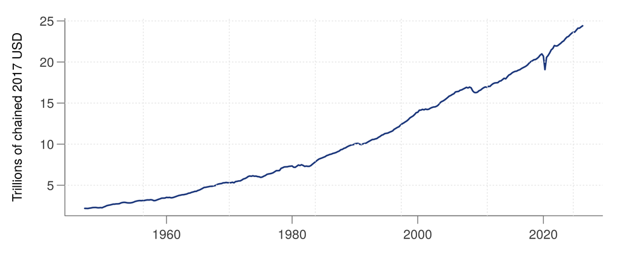

Figure 1: Real GDP (GDPC1), level. A trending series: not stationary.

```r
nice_par()
plot(raw$date, raw$value / 1000, type = "l", lwd = 2, col = navy, xlab = "", ylab = "Trillions of chained 2017 USD")
grid(col = "grey90")
```

# 2 Data processing: trends, outliers and stationarity

## 2.1 Trends: from the level to the growth rate

The level trends upward, so we model its growth rate $y_t = 100\,\Delta \log Y_t$ (percent per quarter). Since `GDPC1` is already seasonally adjusted at the source, no seasonal step is needed. A raw series would go through X-13ARIMA-SEATS, e.g. with `seasonal::seas()`.

**Show the R code**

```r
dat <- data.frame(date = raw$date[-1], y = 100 * diff(log(raw$value)))
dat <- dat[dat$date >= est_start, ]

y          <- dat$y                                            # raw growth: used to EVALUATE
Tn         <- length(y)                                        # number of quarters = position of T
covid_flag <- dat$date >= covid[1] & dat$date <= covid[2]
```

## 2.2 Outliers and intervention: winsorisation

A few crisis quarters are so extreme that they would dominate any estimate. The bounds are the 0.5% and 99.5% quantiles of the **whole sample**, but the clipping is applied **only in the two crisis windows**: the Great Financial Crisis (2007Q4–2009Q2) and COVID (2020Q1–2021Q4): $y^w_t = \min\big(\max(y_t, q_{lo}),\, q_{hi}\big)$ in those quarters, $y^w_t = y_t$ otherwise. Only the series fed to the AR(1) is clipped. Forecasts are always judged against the raw data.

**Show the R code**

```r
tail_share <- (1 - winsor_level) / 2                                    # 0.005 in each tail
q_lo <- stats::quantile(y, tail_share,     names = FALSE)               # bounds from the whole sample
q_hi <- stats::quantile(y, 1 - tail_share, names = FALSE)

crisis <- (dat$date >= gfc[1] & dat$date <= gfc[2]) | covid_flag        # GFC or COVID quarter

y_est         <- y                                                      # winsorised series: used to ESTIMATE
y_est[crisis] <- pmin(pmax(y[crisis], q_lo), q_hi)                      # clip only in the crisis windows

iR    <- which(dat$date >= eval_start)[1]                      # position of R
est_i <- 1:iR
y0    <- y_est[est_i]                                          # estimation sample
T0    <- length(y0)
```

Quarters 166 1985Q1–2026Q2

Mean growth 0.65% per quarter, sd 1.04

Estimation sample 100 up to R = 2009Q4

Clipped quarters 2 bounds [-3.26, 2.80]

**Show the R code**

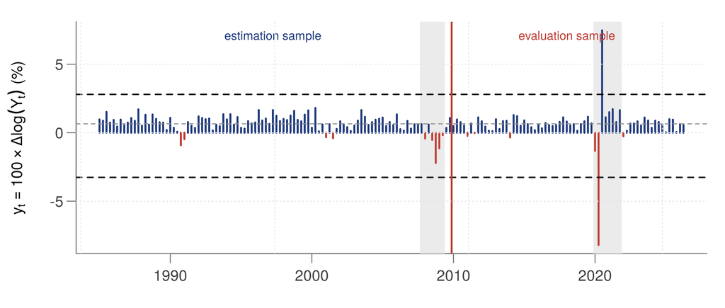

Figure 2: Quarterly growth $y_t$. Grey bands: crisis windows where winsorisation applies (GFC, COVID). Dashed black lines: winsorisation bounds. Red line: R, the end of the estimation sample.

```r
nice_par()
plot(dat$date, dat$y, type = "h", lwd = 2, col = ifelse(dat$y >= 0, navy, red), xlab = "",
     ylab = expression(y[t] == 100 %*% Delta * log(Y[t]) ~ "(%)"))
for (w in list(gfc, covid)) rect(w[1] - 45, par("usr")[3], w[2] + 45, par("usr")[4], col = "grey92", border = NA)
lines(dat$date, dat$y, type = "h", lwd = 2, col = ifelse(dat$y >= 0, navy, red))
abline(h = mean(y), lty = 2, col = grey)
abline(h = c(q_lo, q_hi), lty = 2, lwd = 1.5, col = "black")
abline(v = dat$date[iR] + 45, col = red, lwd = 2)
mtext("estimation sample", side = 3, at = dat$date[round(iR / 2)],        line = -1.2, cex = .8, col = navy)
mtext("evaluation sample", side = 3, at = dat$date[round((iR + Tn) / 2)], line = -1.2, cex = .8, col = red)
grid(col = "grey90")
```

## 2.3 Cycles: autocorrelation and partial autocorrelation

The ACF measures the correlation between $y_t$ and $y_{t-k}$. The PACF measures the same correlation after removing the lags in between. A PACF that cuts off after lag $p$ points to an AR($p$).

**Show the R code**

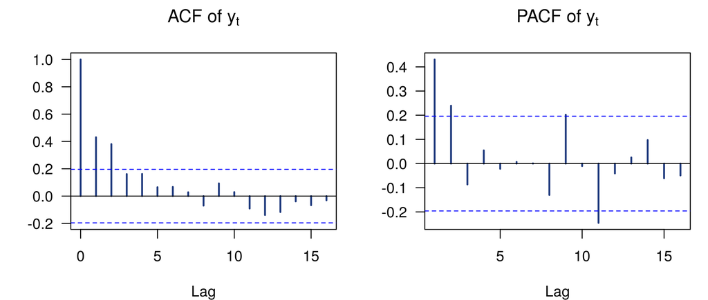

Figure 3: ACF and PACF of growth, estimation sample.

```r
par(mfrow = c(1, 2), mar = c(4, 4, 3, 1), las = 1)
stats::acf(y0,  lag.max = 16, main = expression("ACF of " * y[t]),  col = navy, lwd = 2, ylab = "")
stats::pacf(y0, lag.max = 16, main = expression("PACF of " * y[t]), col = navy, lwd = 2, ylab = "")
pacf_values <- stats::pacf(y0, lag.max = 4, plot = FALSE)$acf[, 1, 1]
```

The partial autocorrelation is **0.43** at lag 1 and **0.24** at lag 2 (95% band $\pm$ 0.20): growth has a short memory.

## 2.4 Stationarity: augmented Dickey–Fuller test

We regress $\Delta x_t = a + \rho\, x_{t-1} + \sum_{i=1}^{k} b_i \Delta x_{t-i}\ (+\ \text{trend}) + u_t$ and test $H_0: \rho = 0$ (unit root) with `urca::ur.df()`: constant and trend for the level, constant only for growth, 4 lagged differences. The ADF statistic is the $t$-statistic of $\rho$ (`tau`); we reject a unit root when it is below the critical value.

**Show the R code**

```r
log_level <- 100 * log(raw$value[raw$date >= est_start & raw$date <= dat$date[iR]])   # estimation sample

adf_lvl <- urca::ur.df(log_level, type = "trend", lags = adf_lags, selectlags = "Fixed")  # level: constant + trend
adf_gr  <- urca::ur.df(y[est_i],  type = "drift", lags = adf_lags, selectlags = "Fixed")  # growth: constant

adf_level  <- adf_lvl@teststat[1, "tau3"]          # ADF statistic, level
adf_growth <- adf_gr@teststat[1, "tau2"]           # ADF statistic, growth
crit_trend <- adf_lvl@cval["tau3", ]               # critical values 1%, 5%, 10%
crit_const <- adf_gr@cval["tau2", ]

summary(adf_gr)                                    # full output of the test on growth
```

```
###############################################
# Augmented Dickey-Fuller Test Unit Root Test #
###############################################

Test regression drift


Call:
lm(formula = z.diff ~ z.lag.1 + 1 + z.diff.lag)

Residuals:
     Min       1Q   Median       3Q      Max
-2.53993 -0.32860  0.02761  0.33595  1.07169

Coefficients:
            Estimate Std. Error t value Pr(>|t|)
(Intercept)  0.31599    0.11891   2.657  0.00933 **
z.lag.1     -0.46946    0.14642  -3.206  0.00187 **
z.diff.lag1 -0.16983    0.15661  -1.084  0.28111
z.diff.lag2  0.07604    0.15130   0.503  0.61650
z.diff.lag3 -0.01897    0.15133  -0.125  0.90052
z.diff.lag4  0.04001    0.12496   0.320  0.74959
---
Signif. codes:  0 '***' 0.001 '**' 0.01 '*' 0.05 '.' 0.1 ' ' 1

Residual standard error: 0.565 on 89 degrees of freedom
Multiple R-squared:  0.3287,    Adjusted R-squared:  0.291
F-statistic: 8.715 on 5 and 89 DF,  p-value: 9.314e-07


Value of test-statistic is: -3.2064 5.1786

Critical values for test statistics:
      1pct  5pct 10pct
tau2 -3.51 -2.89 -2.58
phi1  6.70  4.71  3.86
```

**Show the R code**

```r
tab(data.frame(
  Series           = c("$100\\log Y_t$ (level)", "$y_t = 100\\Delta\\log Y_t$ (growth)"),
  Deterministics   = c("constant + trend", "constant"),
  `ADF statistic`  = fmt(c(adf_level, adf_growth)),
  `5% critical`    = fmt(c(crit_trend[2], crit_const[2])),
  `Unit root?`     = c(ifelse(adf_level  > crit_trend[2], "not rejected", "**rejected**"),
                       ifelse(adf_growth > crit_const[2], "not rejected", "**rejected**")),
  check.names = FALSE), align = "llccc")
```

| Series | Deterministics | ADF statistic | 5% critical | Unit root? |
| --- | --- | --- | --- | --- |
| $100\log Y_t$ (level) | constant + trend | -1.52 | -3.45 | not rejected |
| $y_t = 100\Delta\log Y_t$ (growth) | constant | -3.21 | -2.89 | **rejected** |

The ADF test does not reject a unit root in the level and rejects it in growth. We therefore model growth.

# 3 Model specification, estimation and diagnostic checking

Everything in this step uses the estimation sample only (1985Q1–2009Q4).

## 3.1 Model specification: choosing the order $p$

For $p = 0,\dots,$ 4 we regress $y_t$ on a constant and $p$ lags, **on the same observations** so that the criteria are comparable: $\text{AIC} = n\log\hat\sigma^2 + 2k$ and $\text{BIC} = n\log\hat\sigma^2 + k\log n$. Smaller is better.

**Show the R code**

```r
ic <- as.data.frame(t(sapply(0:p_max, function(p) {
  yy <- y0[(p_max + 1):T0]
  X  <- cbind(rep(1, length(yy)), if (p > 0) sapply(1:p, function(i) y0[(p_max + 1 - i):(T0 - i)]))
  n  <- length(yy)
  e  <- yy - X %*% solve(crossprod(X), crossprod(X, yy))
  s2 <- sum(e^2) / n; k <- ncol(X) + 1
  c(p = p, AIC = n * log(s2) + 2 * k, BIC = n * log(s2) + log(n) * k)
})))
best <- function(v) which(v == min(v))
bold <- function(v) ifelse(seq_along(v) == best(v), paste0("**", fmt(v), "**"), fmt(v))
tab(data.frame(`AR order p` = ic$p, AIC = bold(ic$AIC), BIC = bold(ic$BIC), check.names = FALSE), align = "ccc")
```

| AR order p | AIC | BIC |
| --- | --- | --- |
| 0 | -86.34 | -81.21 |
| 1 | -104.32 | -96.63 |
| 2 | **-107.79** | **-97.54** |
| 3 | -106.54 | -93.72 |
| 4 | -104.78 | -89.39 |

AIC selects $p =$ 2 and BIC selects $p =$ 2. We keep the AR(1): it is simple, transparent, and a standard benchmark that any richer model has to beat.

## 3.2 Estimation: OLS and maximum likelihood

Regress $y_t$ on $(1, y_{t-1})$. This gives $\hat\beta = (X'X)^{-1}X'y$, $\hat\sigma^2 = \hat e'\hat e/(n-2)$ and $\text{se} = \sqrt{\text{diag}((X'X)^{-1})\,\hat\sigma^2}$. As a cross-check we also estimate by maximum likelihood with `stats::arima()`.

**Show the R code**

```r
ar1_ols <- function(y) {
  yy <- y[-1]; X <- cbind(1, y[-length(y)]); n <- length(yy)
  XtXi <- solve(crossprod(X)); b <- XtXi %*% crossprod(X, yy)
  e  <- drop(yy - X %*% b); s2 <- sum(e^2) / (n - 2)
  list(c = b[1], phi = b[2], mu = b[1] / (1 - b[2]), sigma2 = s2, se = sqrt(diag(XtXi) * s2), res = e, n = n)
}
fit      <- ar1_ols(y0)                                        # 1985Q1 - R
fit_full <- ar1_ols(y_est)                                     # 1985Q1 - T (final forecast)
ml       <- stats::arima(y0, order = c(1, 0, 0), method = "ML")
phi_ml   <- unname(stats::coef(ml)[1]); mu_ml <- unname(stats::coef(ml)[2]) # arima reports the MEAN, not c

t_stat <- c(fit$c, fit$phi) / fit$se
p_val  <- 2 * stats::pt(-abs(t_stat), fit$n - 2)
tab(data.frame(
  Parameter       = c("$c$ (intercept)", "$\\phi$ (AR coefficient)", "$\\sigma_\\varepsilon$"),
  `OLS estimate`  = fmt(c(fit$c, fit$phi, sqrt(fit$sigma2)), 3),
  `Std. error`    = c(fmt(fit$se, 3), ""),
  `t-stat`        = c(fmt(t_stat), ""),
  `p-value`       = c(fmt(p_val, 3), ""),
  `ML (arima)`    = fmt(c(mu_ml * (1 - phi_ml), phi_ml, sqrt(ml$sigma2)), 3),
  check.names = FALSE), align = "lccccc")
```

| Parameter | OLS estimate | Std. error | t-stat | p-value | ML (arima) |
| --- | --- | --- | --- | --- | --- |
| $c$ (intercept) | 0.388 | 0.084 | 4.59 | 0.000 | 0.394 |
| $\phi$ (AR coefficient) | 0.432 | 0.092 | 4.72 | 0.000 | 0.429 |
| $\sigma_\varepsilon$ | 0.566 |  |  |  | 0.558 |

Persistence $\hat\phi$ 0.432 s.e. 0.092

Mean growth $\hat\mu$ 0.68% per quarter, ≈ 2.7% a year

Shock size $\hat\sigma_\varepsilon$ 0.57 percentage points

**Why winsorise? The full sample tells the story**

On the estimation sample, winsorisation changes almost nothing: $\hat\phi =$ 0.432 on the raw data, because the clipped quarters fall in COVID, after R. On the **full** sample it matters a lot: $\hat\phi =$ 0.235 winsorised against -0.128 raw. 2 quarters out of 166 would otherwise rewrite the dynamics of the whole model.

## 3.3 Diagnostic checking

A well-specified model leaves residuals that are white noise. We check four properties: no autocorrelation (Ljung–Box), normality (Jarque–Bera), constant variance (Ljung–Box on $\hat\varepsilon_t^2$), and stationarity ($\lvert\hat\phi\rvert < 1$).

**Show the R code**

```r
diag_tests <- function(res, phi) {
  skew <- mean((res - mean(res))^3) / stats::sd(res)^3
  kurt <- mean((res - mean(res))^4) / stats::sd(res)^4
  jb   <- length(res) / 6 * (skew^2 + (kurt - 3)^2 / 4)
  list(lb4  = stats::Box.test(res, lag = 4, type = "Ljung-Box", fitdf = 1)$p.value,
       lb8  = stats::Box.test(res, lag = 8, type = "Ljung-Box", fitdf = 1)$p.value,
       jb   = stats::pchisq(jb, 2, lower.tail = FALSE),
       arch = stats::Box.test(res^2, lag = 4, type = "Ljung-Box")$p.value,
       sk = skew, ku = kurt, phi = abs(phi))
}
d_est  <- diag_tests(fit$res,      fit$phi)
d_full <- diag_tests(fit_full$res, fit_full$phi)
reading <- function(p) ifelse(p > .05, "OK", "**rejected**")
pv <- function(p) fmt(p, 3)

tab(data.frame(
  Property  = c("No autocorrelation", "No autocorrelation", "Normality", "Constant variance", "Stationarity"),
  Test      = c("Ljung-Box, 4 lags", "Ljung-Box, 8 lags", "Jarque-Bera", "Ljung-Box on $\\hat\\varepsilon_t^2$", "$\\lvert\\hat\\phi\\rvert$ (should be < 1)"),
  `p (est.)` = c(pv(d_est$lb4),  pv(d_est$lb8),  pv(d_est$jb),  pv(d_est$arch),  fmt(d_est$phi)),
  `p (full)` = c(pv(d_full$lb4), pv(d_full$lb8), pv(d_full$jb), pv(d_full$arch), fmt(d_full$phi)),
  `Reading (est.)` = c(reading(d_est$lb4), reading(d_est$lb8), reading(d_est$jb), reading(d_est$arch),
                       ifelse(d_est$phi < 1, "OK", "**rejected**")),
  check.names = FALSE), align = "llccl")
```

| Property | Test | p (est.) | p (full) | Reading (est.) |
| --- | --- | --- | --- | --- |
| No autocorrelation | Ljung-Box, 4 lags | 0.040 | 0.744 | **rejected** |
| No autocorrelation | Ljung-Box, 8 lags | 0.095 | 0.923 | OK |
| Normality | Jarque-Bera | 0.000 | 0.000 | **rejected** |
| Constant variance | Ljung-Box on $\hat\varepsilon_t^2$ | 0.561 | 0.000 | OK |
| Stationarity | $\lvert\hat\phi\rvert$ (should be < 1) | 0.43 | 0.24 | OK |

**Show the R code**

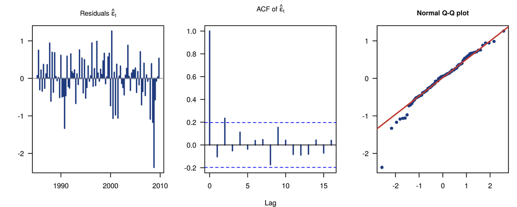

Figure 4: Residuals of the AR(1), estimation sample: time series, ACF and normal Q-Q plot.

```r
res_dates <- dat$date[est_i][-1]
par(mfrow = c(1, 3), mar = c(4, 3.8, 3, 1), las = 1, cex.main = .95)
plot(res_dates, fit$res, type = "h", col = navy, lwd = 2, xlab = "", ylab = "", main = expression("Residuals " * hat(epsilon)[t]))
abline(h = 0, col = grey)
stats::acf(fit$res, lag.max = 16, main = expression("ACF of " * hat(epsilon)[t]), col = navy, lwd = 2, ylab = "")
qqnorm(fit$res, main = "Normal Q-Q plot", pch = 16, col = navy, xlab = "", ylab = "")
qqline(fit$res, col = red, lwd = 2)
```

Residual skewness is -0.84 and kurtosis is 5.17 (3 for a normal distribution). Heavy tails come from the 2008–09 recession.

# 4 Point and density forecasts: the iterated approach

For an AR(1) the forecasts and their uncertainty have closed forms:

$$\hat y_{T+h|T} = \mu + \phi^h (y_T - \mu), \qquad
\text{Var}(e_{T+h|T}) = \sigma^2 \sum_{j=0}^{h-1}\phi^{2j}, \qquad
y_{T+h}\mid\Omega_T \sim N\!\big(\hat y_{T+h|T},\ \text{Var}(e_{T+h|T})\big).$$

The forecast reverts to the mean $\mu$ at speed $\phi$, and the bands widen with $h$ towards the unconditional variance.

**Show the R code**

```r
ar1_forecast <- function(t, H) {                               # forecast made at origin t
  f <- ar1_ols(y_est[1:t]); h <- 1:H
  data.frame(h = h, yhat = f$mu + f$phi^h * (y_est[t] - f$mu),
             sd = sqrt(f$sigma2 * sapply(h, function(k) sum(f$phi^(2 * (0:(k - 1)))))))
}
fc     <- ar1_forecast(Tn, H)                                  # model estimated on 1985Q1 - T
fdates <- as.Date(sapply(1:H, function(k) add_q(max(dat$date), k)), origin = "1970-01-01")

tab(data.frame(Quarter = qlab(fdates), h = fc$h, Forecast = fmt(fc$yhat), `Std. dev.` = fmt(fc$sd),
               `80% interval` = paste0("[", fmt(fc$yhat - stats::qnorm(.9) * fc$sd), ", ", fmt(fc$yhat + stats::qnorm(.9) * fc$sd), "]"),
               `95% interval` = paste0("[", fmt(fc$yhat - stats::qnorm(.975) * fc$sd), ", ", fmt(fc$yhat + stats::qnorm(.975) * fc$sd), "]"),
               `Annualised` = paste0(fmt(400 * log(1 + fc$yhat / 100), 1), "%"),
               check.names = FALSE), align = "ccccccc",
    caption = paste0("Forecasts made at T = ", qlab(max(dat$date)), " (growth in % per quarter)"))
```

Forecasts made at T = 2026Q2 (growth in % per quarter)

| Quarter | h | Forecast | Std. dev. | 80% interval | 95% interval | Annualised |
| --- | --- | --- | --- | --- | --- | --- |
| 2026Q3 | 1 | 0.62 | 0.65 | [-0.21, 1.46] | [-0.65, 1.90] | 2.5% |
| 2026Q4 | 2 | 0.64 | 0.67 | [-0.22, 1.50] | [-0.67, 1.95] | 2.6% |
| 2027Q1 | 3 | 0.65 | 0.67 | [-0.21, 1.51] | [-0.67, 1.96] | 2.6% |
| 2027Q2 | 4 | 0.65 | 0.67 | [-0.21, 1.51] | [-0.67, 1.96] | 2.6% |

Last observation $y_T$ 0.55% 2026Q2

Forecast $\hat y_{T+1|T}$ 0.62% 2026Q3, ± 1.28 (95%)

Forecast $\hat y_{T+4|T}$ 0.65% 2027Q2, ± 1.32 (95%)

**Show the R code**

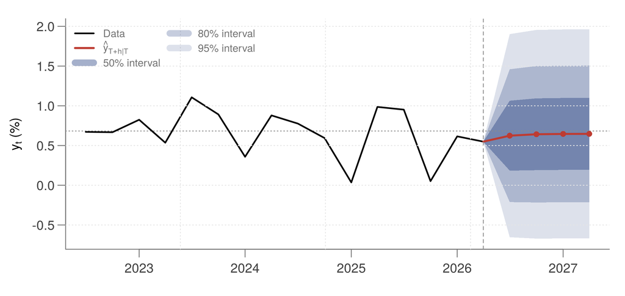

Figure 5: Fan chart: last 16 quarters of data and the forecast with 50 / 80 / 95% intervals.

```r
nice_par()
hist_d <- utils::tail(dat$date, 16); hist_y <- utils::tail(y, 16)
ylim   <- range(c(hist_y, fc$yhat + 2 * fc$sd, fc$yhat - 2 * fc$sd))
plot(c(hist_d, fdates), rep(NA, 16 + H), ylim = ylim, xlab = "", ylab = expression(y[t] ~ "(%)"))
for (level in c(0.95, 0.80, 0.50)) {
  z  <- stats::qnorm(1 - (1 - level) / 2); xs <- c(max(hist_d), fdates)
  lo <- c(utils::tail(y, 1), fc$yhat - z * fc$sd); hi <- c(utils::tail(y, 1), fc$yhat + z * fc$sd)
  polygon(c(xs, rev(xs)), c(lo, rev(hi)), border = NA,
          col = adjustcolor(navy, alpha.f = c("0.95" = .15, "0.8" = .25, "0.5" = .40)[as.character(level)]))
}
abline(h = fit$mu, lty = 3, col = grey)
lines(hist_d, hist_y, lwd = 2, col = "black")
lines(c(max(hist_d), fdates), c(utils::tail(y, 1), fc$yhat), lwd = 2.5, col = red)
points(fdates, fc$yhat, pch = 16, col = red)
abline(v = max(hist_d), lty = 2, col = grey)
grid(col = "grey90")
legend("topleft", bty = "n", cex = .8, ncol = 2, lwd = c(2, 2.5, 8, 8, 8),
       col = c("black", red, adjustcolor(navy, .40), adjustcolor(navy, .25), adjustcolor(navy, .15)),
       legend = c("Data", expression(hat(y)[T + h * "|" * T]), "50% interval", "80% interval", "95% interval"))
```

# 5 Pseudo out-of-sample forecasting exercise

How good would this forecast have been in the past? For every origin $t = R, \dots, T-1$ we:

1. re-estimate the AR(1) on $y_1,\dots,y_t$ only (an expanding window);
2. forecast $h = 1,\dots,H$ quarters ahead;
3. compare with what actually happened, using the **raw** data, never winsorised.

It is *pseudo* real time because we use today’s revised data, not the data available at the time.

**Show the R code**

```r
oos <- do.call(rbind, lapply(iR:(Tn - 1), function(t) {
  f <- ar1_forecast(t, min(H, Tn - t))
  data.frame(origin = dat$date[t], h = f$h, target = dat$date[t + f$h], yhat = f$yhat, sd = f$sd,
             actual = y[t + f$h], covid = covid_flag[t] | covid_flag[t + f$h])
}))
oos$err  <- oos$actual - oos$yhat                              # e_{t+h|t}
oos$pit  <- stats::pnorm(oos$actual, oos$yhat, oos$sd)                # PIT
oos$logs <- stats::dnorm(oos$actual, oos$yhat, oos$sd, log = TRUE)    # log score
oos$in80 <- abs(oos$err) <= stats::qnorm(.90)  * oos$sd
oos$in95 <- abs(oos$err) <= stats::qnorm(.975) * oos$sd

e1 <- oos$err[oos$h == 1]
lb_e1 <- stats::Box.test(e1, lag = 4, type = "Ljung-Box")$p.value
p_mean0 <- stats::t.test(e1)$p.value

show <- utils::head(oos[oos$h == 1, c("origin", "target", "yhat", "sd", "actual", "err", "pit")], 6)
show$origin <- qlab(show$origin); show$target <- qlab(show$target)
show[, 3:7] <- lapply(show[, 3:7], fmt)
tab(show, caption = "First one-step-ahead forecasts (all forecasts are kept in the object `oos`)", align = "ccccccc")
```

First one-step-ahead forecasts (all forecasts are kept in the object `oos`)

| origin | target | yhat | sd | actual | err | pit |
| --- | --- | --- | --- | --- | --- | --- |
| 2009Q4 | 2010Q1 | 0.85 | 0.57 | 0.48 | -0.37 | 0.26 |
| 2010Q1 | 2010Q2 | 0.59 | 0.56 | 0.96 | 0.37 | 0.74 |
| 2010Q2 | 2010Q3 | 0.80 | 0.56 | 0.77 | -0.03 | 0.48 |
| 2010Q3 | 2010Q4 | 0.72 | 0.56 | 0.52 | -0.20 | 0.36 |
| 2010Q4 | 2011Q1 | 0.61 | 0.56 | -0.24 | -0.85 | 0.06 |
| 2011Q1 | 2011Q2 | 0.28 | 0.56 | 0.67 | 0.40 | 0.76 |

There are **66 origins** and **258 forecasts** in total. The mean one-step error is -0.027 (p-value of a zero mean: 0.890), and the Ljung–Box p-value of the one-step errors is 0.040.

# 6 Point and density forecast evaluation

For each horizon we report the bias (mean error), the RMSFE (with and without COVID), the empirical coverage of the 80% and 95% intervals, and the average log score (higher is better).

**Show the R code**

```r
ev <- do.call(rbind, lapply(1:H, function(k) {
  s <- oos[oos$h == k, ]; sx <- s[!s$covid, ]
  data.frame(h = k, n = nrow(s), ME = mean(s$err), RMSFE = sqrt(mean(s$err^2)),
             RMSFE_xc = sqrt(mean(sx$err^2)), cov80 = 100 * mean(s$in80),
             cov95 = 100 * mean(s$in95), LS = mean(s$logs))
}))
tab(data.frame(`$h$` = ev$h, `$N_h$` = ev$n, `Mean error` = fmt(ev$ME), RMSFE = fmt(ev$RMSFE),
               `RMSFE ex-COVID` = fmt(ev$RMSFE_xc), `80% cov.` = paste0(fmt(ev$cov80, 0), "%"),
               `95% cov.` = paste0(fmt(ev$cov95, 0), "%"), `Log score` = fmt(ev$LS), check.names = FALSE),
    align = "cccccccc")
```

| $h$ | $N_h$ | Mean error | RMSFE | RMSFE ex-COVID | 80% cov. | 95% cov. | Log score |
| --- | --- | --- | --- | --- | --- | --- | --- |
| 1 | 66 | -0.03 | 1.56 | 0.39 | 85% | 94% | -4.00 |
| 2 | 65 | -0.04 | 1.50 | 0.37 | 86% | 94% | -3.84 |
| 3 | 64 | -0.06 | 1.49 | 0.37 | 86% | 94% | -3.83 |
| 4 | 63 | -0.06 | 1.50 | 0.37 | 86% | 94% | -3.85 |

**Reading the evaluation**

At $h=1$ the RMSFE is **1.56 pp**, but only **0.39 pp** without the COVID window: a few quarters dominate squared-error measures. The 80% and 95% intervals contain 85% and 94% of the outcomes at $h = 1$, against nominal coverage of 80% and 95%.

**Forecasts vs realised**

**Show the R code**

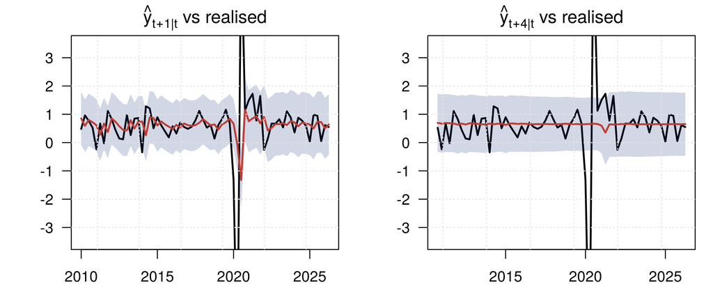

Figure 6: Pseudo out-of-sample forecasts (red) against the realised values (black), with the 90% band. 2020Q2–Q3 fall outside the axis.

```r
par(mfrow = c(1, 2), mar = c(3, 4, 2, 1), las = 1)
for (k in c(1, 4)) {
  s <- oos[oos$h == k, ]
  plot(s$target, s$actual, type = "l", lwd = 2, col = "black", xlab = "", ylab = "",
       main = bquote(hat(y)[t + .(k) * "|" * t] ~ "vs realised"), ylim = c(-3.5, 3.5))
  polygon(c(s$target, rev(s$target)), c(s$yhat - 1.645 * s$sd, rev(s$yhat + 1.645 * s$sd)),
          col = adjustcolor(navy, .2), border = NA)
  lines(s$target, s$yhat, col = red, lwd = 2)
  grid(col = "grey90")
}
```

**RMSFE by horizon**

**Show the R code**

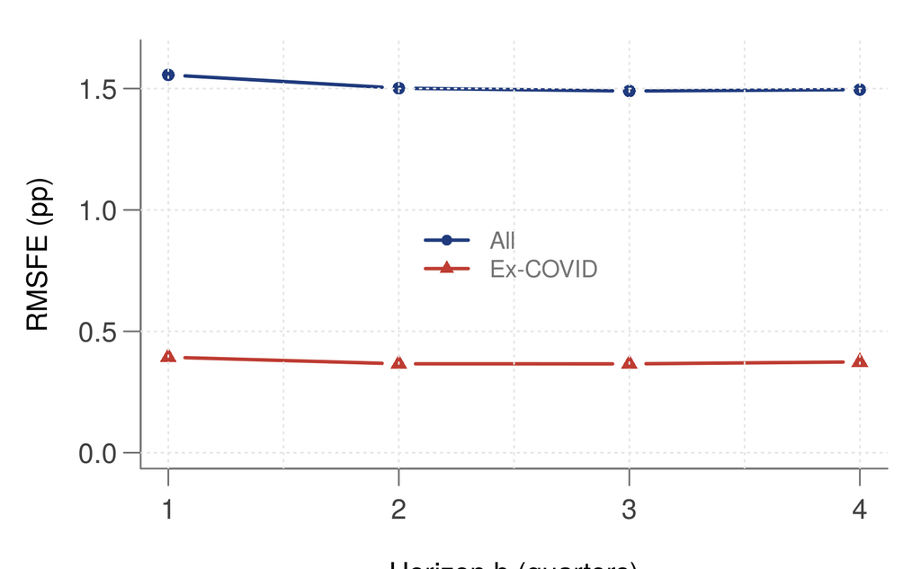

Figure 7: RMSFE by horizon, all quarters and excluding COVID.

```r
nice_par()
plot(ev$h, ev$RMSFE, type = "b", pch = 16, lwd = 2, col = navy, ylim = c(0, max(ev$RMSFE) * 1.05),
     xlab = "Horizon h (quarters)", ylab = "RMSFE (pp)", xaxt = "n")
axis(1, at = 1:H)
lines(ev$h, ev$RMSFE_xc, type = "b", pch = 17, lwd = 2, col = red)
grid(col = "grey90")
legend("center", bty = "n", cex = .85, pch = c(16, 17), lwd = 2, col = c(navy, red), legend = c("All", "Ex-COVID"))
```

**PIT histograms**

**Show the R code**

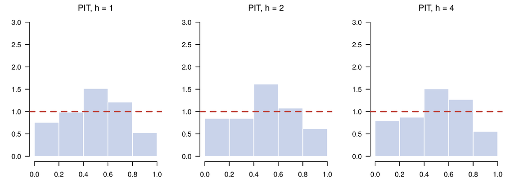

Figure 8: Probability integral transforms. If the density forecasts are right, the PITs are uniform: the histogram is flat at 1 (red dashed line).

```r
par(mfrow = c(1, 3), mar = c(3.5, 3.5, 2, 1), las = 1)
for (k in c(1, 2, 4)) {
  hist(oos$pit[oos$h == k], breaks = seq(0, 1, 0.2), freq = FALSE, col = lightnavy, border = "white",
       main = bquote("PIT, h = " * .(k)), xlab = "", ylab = "", ylim = c(0, 3))
  abline(h = 1, col = red, lwd = 2, lty = 2)
}
```

**What is a PIT? (illustration with made-up numbers)**

The PIT of an outcome is the forecast CDF evaluated at that outcome: $z = F(y)$. Suppose the forecast is $N(0.68, 0.57^2)$ and the realised value is $1.20$. Then $z = F(1.20) =$ 0.82. If the forecast densities are correct, the $z$’s are uniform on $[0,1]$, so $P(z \le u) = u$.

**Show the R code**

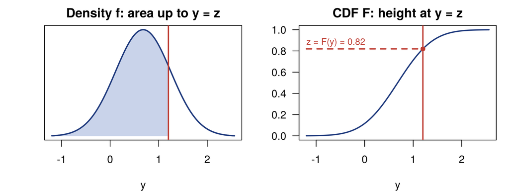

Figure 9: Left: the PIT is the area under the forecast density up to the outcome. Right: the same number read on the CDF.

```r
m_ill <- 0.68; s_ill <- 0.57; y_ill <- 1.20; z_ill <- stats::pnorm(y_ill, m_ill, s_ill)
grid_y <- seq(m_ill - 3.3 * s_ill, m_ill + 3.3 * s_ill, length.out = 300)
par(mfrow = c(1, 2), mar = c(4, 3.5, 2, 1), las = 1)
plot(grid_y, stats::dnorm(grid_y, m_ill, s_ill), type = "l", lwd = 2, col = navy, xlab = "y", ylab = "", yaxt = "n",
     main = "Density f: area up to y = z")
left <- grid_y[grid_y <= y_ill]
polygon(c(left, rev(left)), c(stats::dnorm(left, m_ill, s_ill), rep(0, length(left))), col = lightnavy, border = NA)
lines(grid_y, stats::dnorm(grid_y, m_ill, s_ill), lwd = 2, col = navy); abline(v = y_ill, col = red, lwd = 2)
plot(grid_y, stats::pnorm(grid_y, m_ill, s_ill), type = "l", lwd = 2, col = navy, xlab = "y", ylab = "", ylim = c(0, 1),
     main = "CDF F: height at y = z")
segments(min(grid_y), z_ill, y_ill, z_ill, col = red, lty = 2, lwd = 2)
abline(v = y_ill, col = red, lwd = 2); points(y_ill, z_ill, pch = 16, col = red)
text(min(grid_y), z_ill + .06, bquote("z = F(y) = " * .(round(z_ill, 2))), col = red, adj = 0, cex = .85)
```

# 7 Communication: the vintage table

This is how forecasting divisions track their own forecasts. Each **column** is a vintage $t$ (the model re-estimated with data up to $t$), each **row** is a target quarter, and each **cell** is the forecast of that target made at that vintage. Every coloured diagonal is one horizon $h$. Reading a row from left to right shows how the forecast of one quarter was revised as new data came in.

**Show the R code**

```r
vintages <- utils::tail(dat$date, n_origins)
targets  <- as.Date(sapply(seq_len(n_origins + H - 1), function(k) add_q(vintages[1], k)), origin = "1970-01-01")
fbv      <- lapply(vintages, function(v) ar1_forecast(which(dat$date == v), H)$yhat)

cell <- function(r, i) { h <- r - i + 1
  if (h < 1 || h > H) "<td></td>" else sprintf("<td class='hz%d'>%s</td>", min(h, 4), fmt(fbv[[i]][h])) }
rows <- vapply(seq_along(targets), function(r) {
  real <- if (targets[r] <= max(dat$date)) fmt(y[match(targets[r], dat$date)]) else ""
  paste0("<tr><td style='text-align:left'><b>", qlab(targets[r]), "</b></td><td><b>", real, "</b></td>",
         paste(vapply(seq_len(n_origins), function(i) cell(r, i), ""), collapse = ""), "</tr>")
}, "")
cat("<table class='vintage'><thead><tr><th style='text-align:left'>Target (rows) / vintage t (columns)</th><th>Realised y</th>",
    paste0("<th>", qlab(vintages), "</th>", collapse = ""), "</tr></thead><tbody>",
    paste(rows, collapse = ""), "</tbody></table>",
    "<p style='text-align:center;font-size:.85rem;color:#5a6475'>Shading: <span style='background:#dbe4f5;padding:0 .4rem'>h = 1</span> ",
    "<span style='background:#e8eefa;padding:0 .4rem'>h = 2</span> <span style='background:#f3dcd9;padding:0 .4rem'>h = 3</span> ",
    "<span style='background:#f9ecea;padding:0 .4rem'>h = 4</span></p>", sep = "")
```

| Target (rows) / vintage t (columns) | Realised y | 2025Q1 | 2025Q2 | 2025Q3 | 2025Q4 | 2026Q1 | 2026Q2 |
| --- | --- | --- | --- | --- | --- | --- | --- |
| **2025Q2** | **0.99** | 0.50 |  |  |  |  |  |
| **2025Q3** | **0.95** | 0.61 | 0.73 |  |  |  |  |
| **2025Q4** | **0.05** | 0.64 | 0.67 | 0.72 |  |  |  |
| **2026Q1** | **0.62** | 0.64 | 0.66 | 0.67 | 0.51 |  |  |
| **2026Q2** | **0.55** |  | 0.65 | 0.66 | 0.61 | 0.64 |  |
| **2026Q3** |  |  |  | 0.65 | 0.64 | 0.65 | 0.62 |
| **2026Q4** |  |  |  |  | 0.65 | 0.65 | 0.64 |
| **2027Q1** |  |  |  |  |  | 0.65 | 0.65 |
| **2027Q2** |  |  |  |  |  |  | 0.65 |

Shading: h = 1 h = 2 h = 3 h = 4

# Practical use for decision making: where judgement comes in

The AR(1) is a benchmark, not the final forecast. In a central bank or a research institute, the model output is the starting point of a discussion:

- **Mean reversion.** With $\hat\phi =$ 0.24 the forecast is back near the mean $\hat\mu =$ 0.65% within a couple of quarters. The model knows nothing about the business cycle, policy or news.
- **Exceptional periods.** Winsorising the crisis quarters is one way to keep the GFC and COVID from distorting the model. Others are common in practice:
  - *dummy variables* (one per extreme quarter) in the regression, so those quarters do not move $\hat\phi$ or $\hat\sigma$;
  - a *COVID factor*, as in Stock and Watson (2025), which captures the pandemic-specific comovements on top of the usual factors;
  - simply *not assessing* the model in that period: drop the COVID quarters from the evaluation (the “ex-COVID” RMSFE above);
  - *fat-tailed or time-varying errors* (Student-$t$ shocks, stochastic volatility, outlier-adjusted models), so the density forecasts widen when volatility jumps.
- **Real time.** GDP is revised. A true real-time exercise would use the data as published at each date (`fredr`’s `realtime_start` / `realtime_end` or ALFRED), which usually makes past forecasts look worse.
- **Judgement and conditioning.** Forecasters overlay information the model ignores (surveys, high-frequency indicators, known shocks) and document every deviation from the model in the vintage table.
- **Beating the benchmark.** Any richer model (AR($p$), VAR, factor model, nowcast) should be compared with this one on the same pseudo out-of-sample design and the same metrics.

**Reproducibility**

Rendered on 13 October 2026 at 10:15 with R version 4.3.3 (2024-02-29). Data source: saved copy data/GDPC1_snapshot.csv, last observation 2026Q2.

```
R version 4.3.3 (2024-02-29)
```

**References.** Grobéty, M., *Economic Forecasting for Decision Making*, lecture slides. Vermandel, G., *Building a Sample for Time Series Analysis*. Hamilton, J. (1994), *Time Series Analysis*, Princeton UP. Boysel, S. and Vaughan, D., `fredr`: an R client for the FRED API.